# Informe Estandarización Perú Escala DINI

### Histogramas

Veamos el histograma de cada variable:

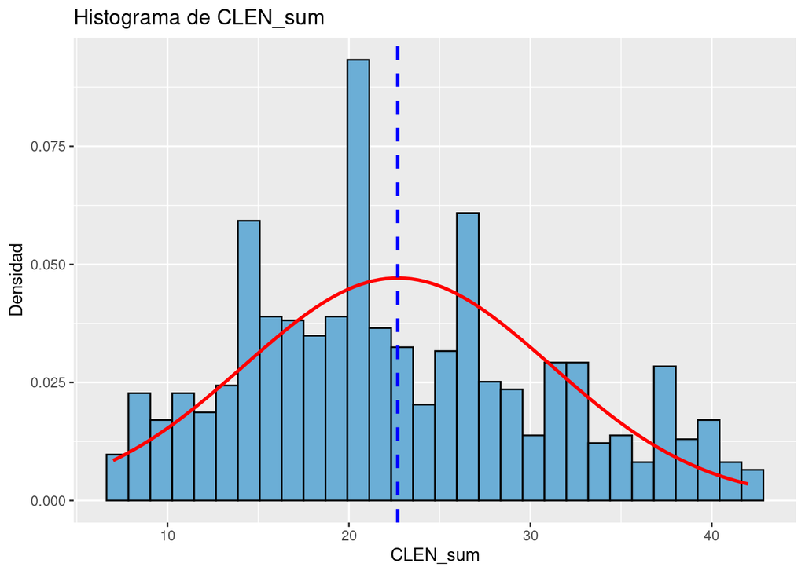

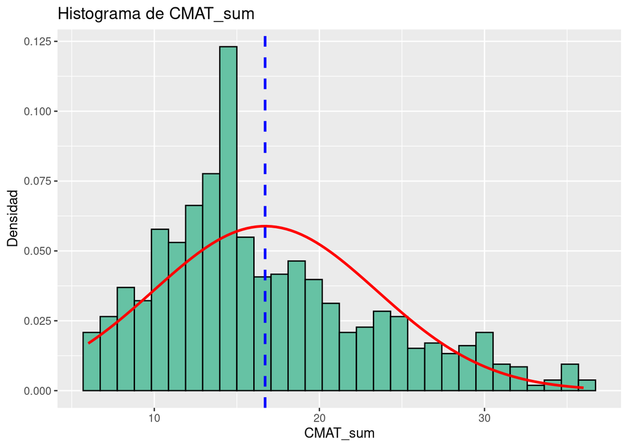

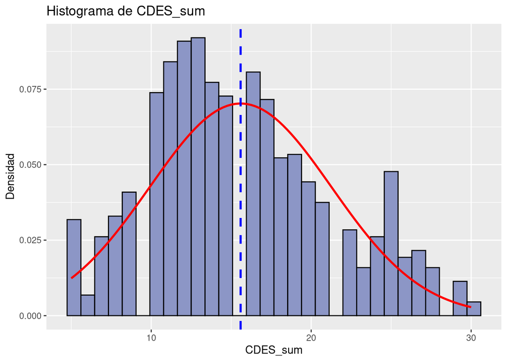

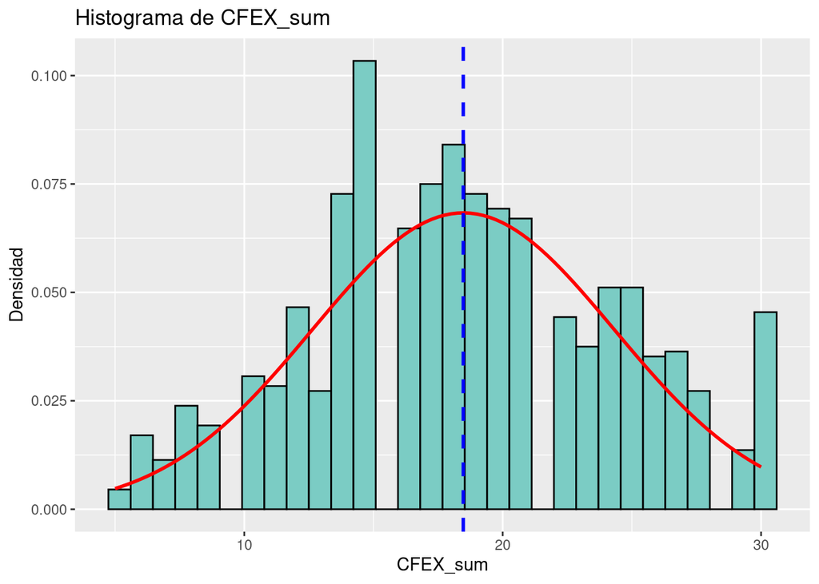

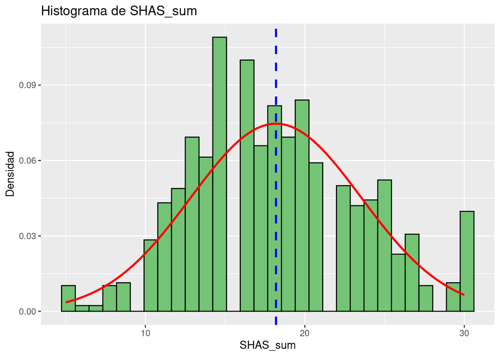

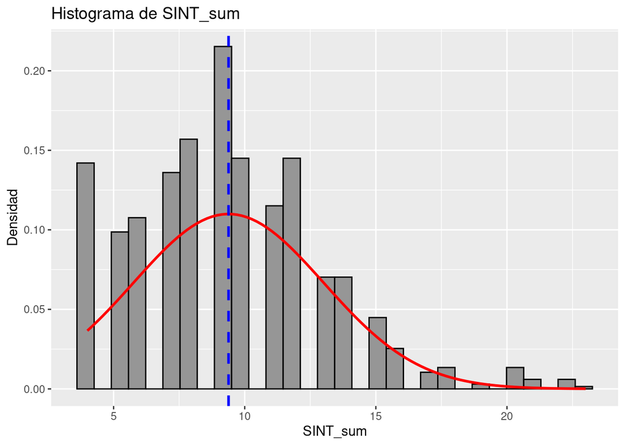

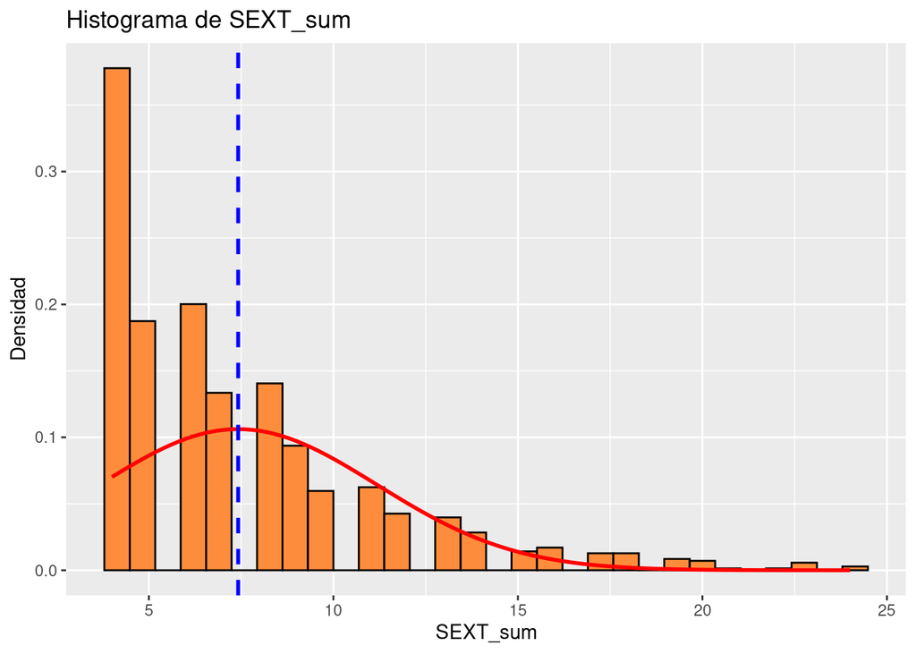

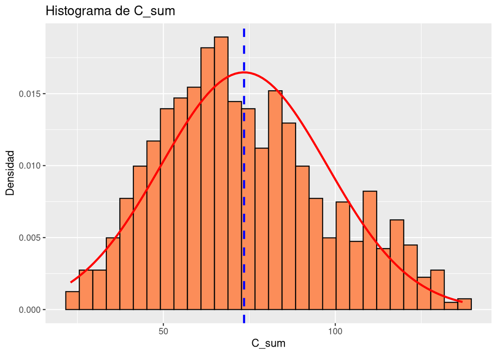

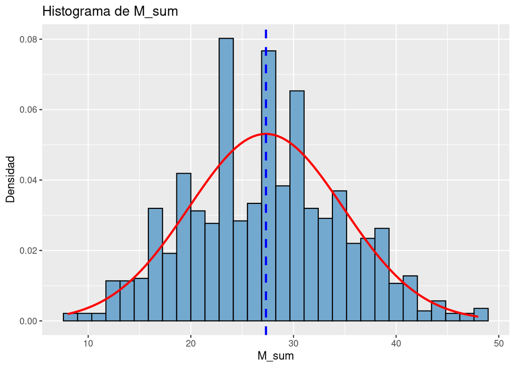

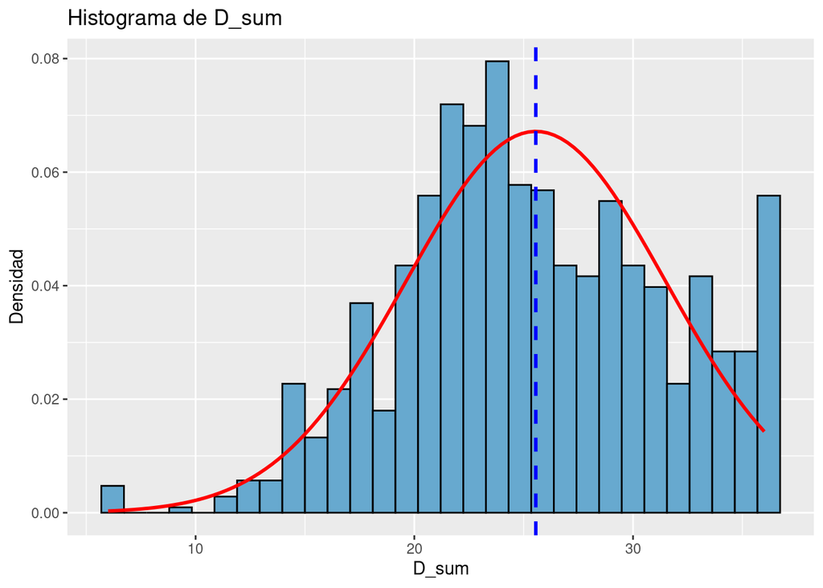

### Normalidad

Empezaremos por hacer una comparación gráfica de la distribución de las subescalas y la distribución normal hipotética.

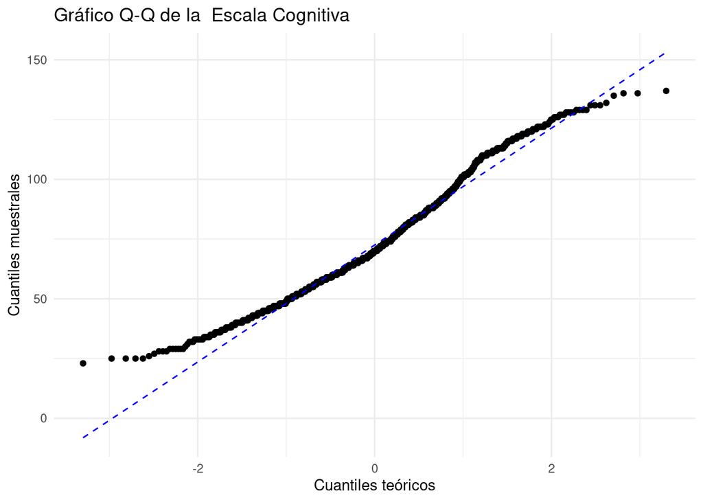

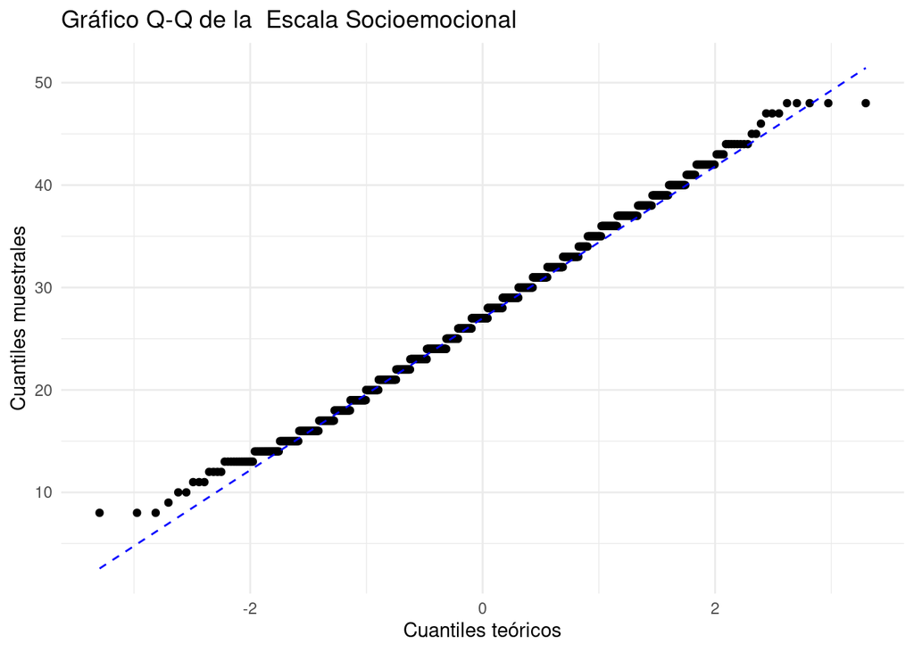

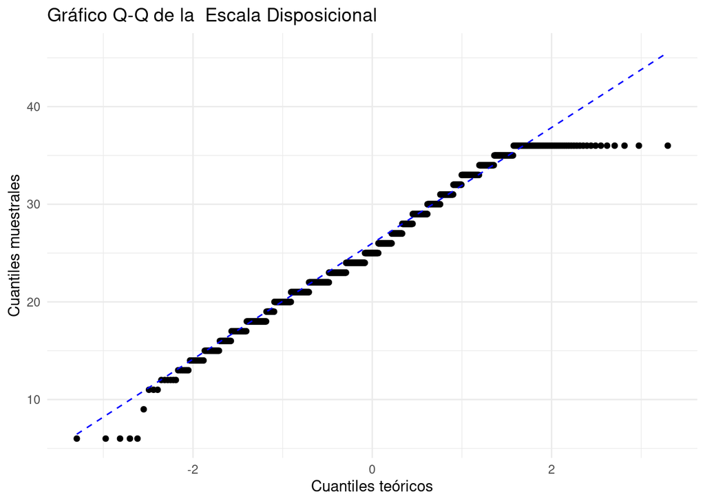

Pasemos a calcular los estadísticos de normalidad correspondientes a las subescalas DINI:

Resultados de los tests de normalidad (S-W, Lilliefors K-S)

|  | Shapiro_Wilk | Lilliefors_KS |
| --- | --- | --- |
| CLEN_sum | p = 0.00 *** (No se puede asumir normalidad) | p = 0.00 *** (No se puede asumir normalidad) |
| CMAT_sum | p = 0.00 *** (No se puede asumir normalidad) | p = 0.00 *** (No se puede asumir normalidad) |
| CDES_sum | p = 0.00 *** (No se puede asumir normalidad) | p = 0.00 *** (No se puede asumir normalidad) |
| CFEX_sum | p = 0.00 *** (No se puede asumir normalidad) | p = 0.00 *** (No se puede asumir normalidad) |
| SHAS_sum | p = 0.00 *** (No se puede asumir normalidad) | p = 0.00 *** (No se puede asumir normalidad) |
| SINT_sum | p = 0.00 *** (No se puede asumir normalidad) | p = 0.00 *** (No se puede asumir normalidad) |
| SEXT_sum | p = 0.00 *** (No se puede asumir normalidad) | p = 0.00 *** (No se puede asumir normalidad) |
| C_sum | p = 0.00 *** (No se puede asumir normalidad) | p = 0.00 *** (No se puede asumir normalidad) |
| M_sum | p = 0.00 ** (No se puede asumir normalidad) | p = 0.00 *** (No se puede asumir normalidad) |
| D_sum | p = 0.00 *** (No se puede asumir normalidad) | p = 0.00 *** (No se puede asumir normalidad) |

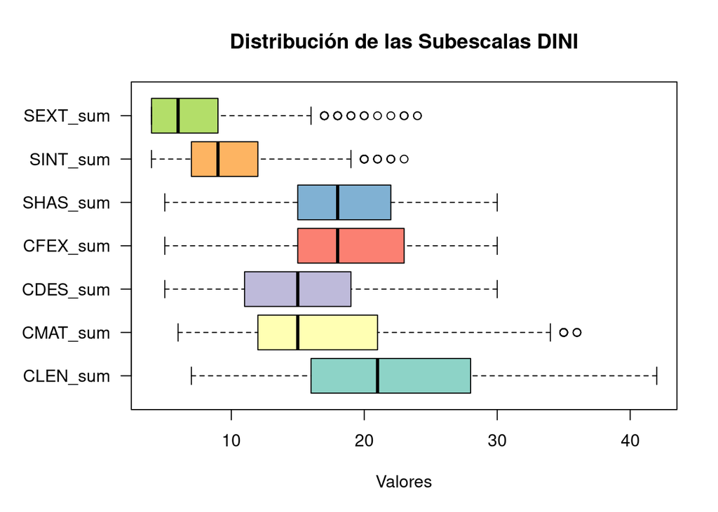

### Confiabilidad

Pasemos ahora a calcular los índices de confiabilidad alpha de Cronbach para las subescalas DINI.

Confiabilidad de la Escala C

| Std.Alpha | Cantidad.Items.Prescindibles | Items |
| --- | --- | --- |
| 0.96 | 0 | no hay ítems cuya exclusión incremente alpha en más de 0.05 puntos |

Confiabilidad de la Escala M

| Std.Alpha | Cantidad.Items.Prescindibles | Items |
| --- | --- | --- |
| 0.84 | 0 | no hay ítems cuya exclusión incremente alpha en más de 0.05 puntos |

Confiabilidad de la Escala S

| Std.Alpha | Cantidad.Items.Prescindibles | Items |
| --- | --- | --- |
| 0.8 | 0 | No hay ítems cuya exclusión incremente alpha en más de 0.05 puntos |

Confiabilidad de la Escala D

| Std.Alpha | Cantidad.Items.Prescindibles | Items |
| --- | --- | --- |
| 0.87 | 0 | no hay ítems cuya exclusión incremente alpha en más de 0.05 puntos |

De los índices obtenidos podemos establecer que las subescalas DINI muestran una gran confiabilidad; es decir, miden de forma consistente, sin que exista ítems que vayan en detrimento de la confiabilidad general. Por el contrario, todos los reactivos ostentan consistencia con los demás.

### Análisis Factorial

Pasaremos a evaluar la validez de la Escala DINI en su aplicación a la muestra peruana 2024.

En el contexto de uso del análisis psicométrico de esta escala, el objetivo es corroborar que la estructura de las variables a evaluar se ha mantenido constante en esta aplicación.

Debido a que estamos analizando una escala ya construida y validada en su población original (Uruguay), nuestra tarea en este punto es establecer si la estructura factorial del instrumento se reproduce razonablemente bien en nuestra muestra proveniente de la población peruana.

A fin de determinar esto, procederemos a realizar la variante llamada Análisis Factorial Confirmatorio (AFC).

### Resumen de Índices de Bondad de Ajuste para el AFC de la Escala DINI

Resumen de Índices de Bondad de Ajuste para el AFC de la Escala DINI

|  | Índice | Índice.Obtenido | Nivel.Obtenido |
| --- | --- | --- | --- |
| rmsea | RMSEA | 0.0875521 | Deficiente |
| cfi | CFI | 0.7438284 | Deficiente |
| tli | TLI/NNFI | 0.7315567 | Deficiente |
| srmr | SRMR | 0.0812253 | Aceptable |
| gfi | GFI | 0.6399880 | Deficiente |